# Hitter Development Report

← Team overview · League overview

# George Springer

**2026 season · Profile: Balanced · xwOBA 0.306 (27th percentile)**

George Springer squares up the ball at an average rate (41st percentile) with bat speed in the 64th percentile. Main lever: **maintain the swing; look for gains in decisions and timing.**

## Swing profile vs MLB

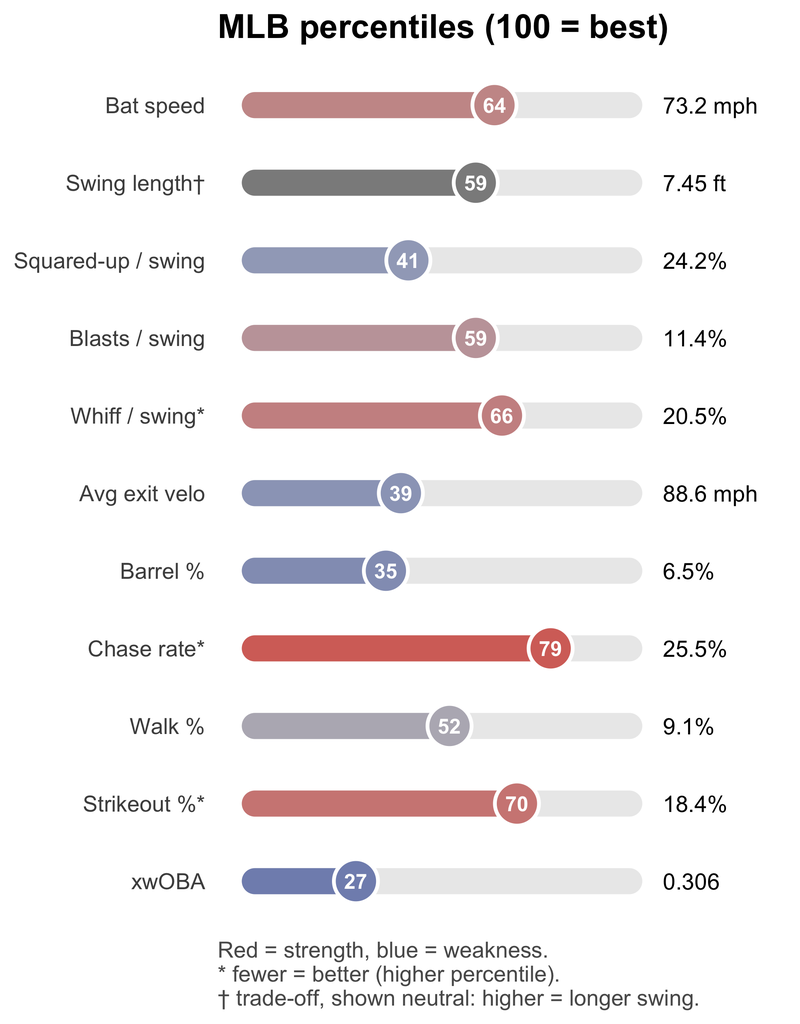

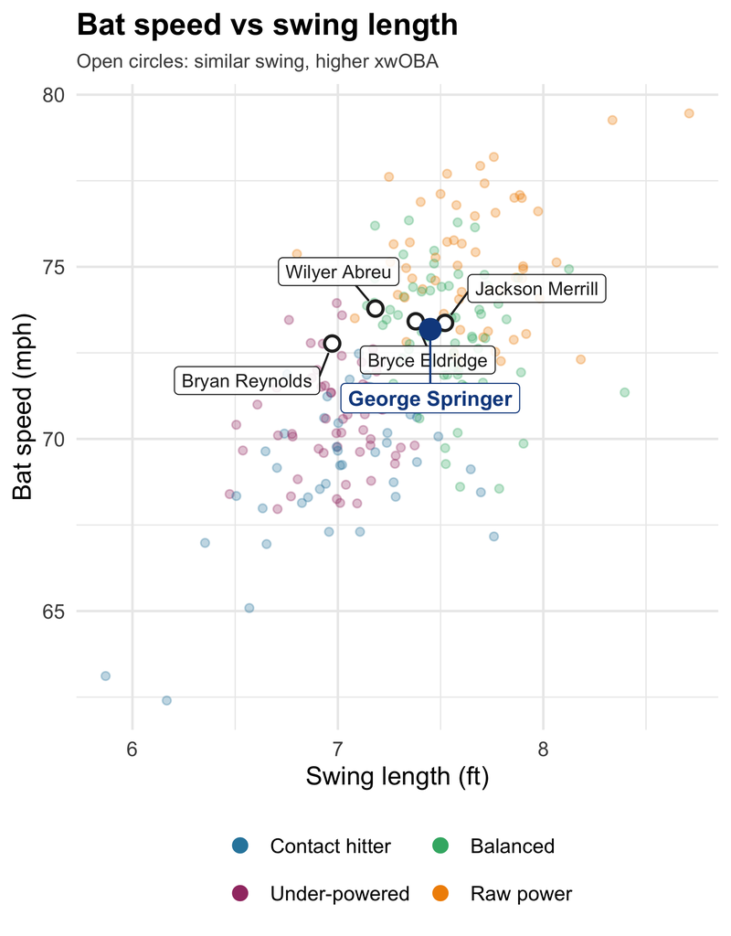

## Year-over-year

| Season | Bat speed (mph) | Swing length (ft) | Squared-up / swing | Whiff / swing | xwOBA | wOBA (actual) |
| --- | --- | --- | --- | --- | --- | --- |
| 2025 | 73.8 | 7.50 | 24.5% | 24.9% | 0.404 | 0.408 |
| 2026 | 73.2 | 7.45 | 24.2% | 20.5% | 0.306 | 0.320 |
| Change | -0.6 | -0.05 | -0.3 pts | -4.4 pts | -0.098 | -0.088 |

**From 2025 to 2026:** bat speed fell 0.6 mph, squared-up rate fell 0.3 pts and xwOBA fell 98 points.

## What the model says

Across 232 qualified MLB hitters in 2026, at equal swing length, contact and whiff rate, **+1 mph of bat speed is associated with +10 points of xwOBA**, and +1 point of squared-up rate with +4 points. The swing metrics explain 42% of the differences in production between hitters; adding swing decisions (chase and in-zone swing rates) raises it to 47%. The rest comes from timing, launch direction and factors public data does not capture.

These are cross-sectional associations, not guarantees: they set the hypothesis to test with the player, not the expected outcome.

## Development plan

**Diagnosis.** George Springer combines above-average bat speed (64th percentile) with average contact (41st percentile).

**Priority.** Maintain the swing; marginal gains are more likely in swing decisions and timing than in mechanics.

1. **Monitor** – Track bat speed across the season to catch fatigue-related drops.
2. **Explore** – Chase and in-zone decisions with the hitting coaches.

Reference points – similar swing, higher xwoba

| Comparable hitter | Bat speed (mph) | Squared-up / swing | xwOBA |
| --- | --- | --- | --- |
| Bryce Eldridge | 73.4 | 23.8% | 0.359 |
| Bryan Reynolds | 72.8 | 24.7% | 0.355 |
| Jackson Merrill | 73.4 | 22.8% | 0.347 |
| Wilyer Abreu | 73.8 | 24.3% | 0.346 |

Data: Baseball Savant, public Statcast data (bat tracking, expected stats, exit velocity). Bat speed = average of the top 90% of competitive swings. Percentiles (1–100), model and profiles are based on the 232 qualified MLB hitters in 2026 (570+ competitive swings). Profiles: k-means on bat speed, swing length, squared-up and whiff rates. Internal biomechanics data would replace the screening hypotheses with measured values. Report: Hugo Leligny.

Hugo Leligny · Sport Scientist & Performance Analyst  
Measure → Analyze → Decide → Train → Monitor → Adapt ↻  
hugoleligny14@gmail.com · [GitHub](https://github.com/hugollel/blue-jays-hitting)